# Gene Analysis

jhhornn

2024-01-14

### RNA-SEQ Gene Expression Analysis

#### Methods of Measuring Gene Expression

- **DNA Microarray**: DNA-DNA hybridization. The mRNA sample is reverse-transcribed to complementary DNA. The DNA is labeled with fluorescent tags. This strand is hybridized with the complementary DNA of the gene(to be measured) on the probe. The probe is washed off to remove unhybridized strands. The intensity of the fluorescent tag shows the level of gene expression. This method can measure gene expression of specific samples or differential expression between samples.
- **RNA-SEQ**: mRNA is reverse transcribed to complementary DNA; the complementary DNA is broken down into fragments and fed to the DNA sequencer, giving out reads mapped to the reference genome. A Gene Quantification Matrix is generated based on the number of reads mapped to the reference genome. Normalization can be performed on the matrix to work with it.

#### The NCBI Site

##### GEO(Gene Expression Omnibus) Datasets

Accessing GEO data requires the use of:

- Accession ID(it’s a unique ID): We’d be working with the ID “GSE183947” which is associated with a breast cancer dataset.
- Keyword.

*It is important to know the kind of nomalization that was performed on a dataset as it affects the conclusion drawn from it.*

##### Analysis of GSE183947 Data

The overview of the few processes involved in the Analysis are described below:

**EDA**

1. Describe what the script does, set working directory, spell out our tasks and state the required packages(with their versions). The directory path varies with where you choose to save your work.

```r
# This script manipulates gene expression data
# setwd("~/Documents/Bioinformatics Projects/Bioinformatics_101")

# Tasks
# Read in expression matrix (FPKM)
# Fetching metadata/clinical data using GEOquery R package
# Demonstrate useful functions to tidy, reshape, join and explore data

#Packages Requires
# dplyr(v1.0.7)
# tidyverse(v1.3.1)
# GEOquery(v2.60.0)
```

2. Load the required libraries

```r
library(tidyverse)
library(GEOquery)
```

3. Read in the data
- Reads a CSV file containing gene expression data (`./GSE183947_fpkm.csv`) into the variable `gse_data`.
- `dim(gse_data)` prints the dimensions (number of rows and columns) of the loaded data.

```r
gse_data <- read.csv(file = "./GSE183947_fpkm.csv")
dim(gse_data)
```

```
## [1] 20246    61
```

```r
head(gse_data)
```

```
##          X CA.102548 CA.104338 CA.105094 CA.109745 CA.1906415 CA.1912627 CA.1924346 CA.1926760 CA.1927842 CA.1933414 CA.1940640 CA.2004407 CA.2005288 CA.2006047 CA.2008260 CA.2009329 CA.2009381 CA.2009850 CA.2017611 CA.2039179 CA.2040686 CA.2045012 CA.2046297 CA.348981 CA.354300 CA.359448 CA.9437…
## 1   TSPAN6      0.93      1.97      0.00      5.45       4.52       4.75       3.96       3.58       6.41      11.89       5.55       3.82       7.66      11.48       4.32      14.44      10.26       6.51       5.86       7.13       9.19       6.65      10.13      7.07      4.76      2.10     4.7…
## 2     TNMD      0.00      0.00      0.00      0.00       0.00       0.00       0.00       0.23       0.39       0.44       0.36       0.09       0.07       1.14       0.00       0.50       0.21       0.20       0.10       0.18       0.20       0.00       0.00      0.00      0.49      0.00     0.2…
## 3     DPM1      0.00      0.43      0.00      3.43       8.45       8.53       7.80       7.62       6.40       6.09       6.62       5.51       9.62       6.77      13.13       9.71       9.01       7.71      18.03       8.32       5.96       9.21       8.60      2.89      6.51      2.72    15.2…
## 4    SCYL3      5.78      5.17      8.76      4.58       7.20       6.03       9.05       5.37       5.92      12.45      10.44       8.81       9.04       9.36       5.91       4.58       8.10      13.55       3.66       4.39       7.46       9.98      15.58      8.54      4.42      4.82     5.7…
## 5 C1orf112      2.83      6.26      3.37      6.24       5.16      13.69       6.69       5.28       7.65      13.71      13.97       7.30      16.13      14.37      10.71       9.87       8.51      16.54      10.59       5.37       8.59      13.38      15.07      8.33      5.01      5.98     8.6…
## 6      FGR      4.80      1.83      0.00      4.23      15.87       8.56      13.28      12.27       5.58       7.03       5.04      12.83       9.56       7.57       9.77      15.40      11.62       8.90       1.87       8.93       9.04       8.44       5.54     15.79      6.42     11.93     8.0…
```

4. Get the metadata from the GEO database
- Retrieves metadata associated with the GEO dataset “GSE183947” using the `getGEO` function.
- `gse` stores the retrieved data, and the object is printed to the console.

```r
gse <- getGEO(GEO = "GSE183947", GSEMatrix = TRUE)
gse
```

```
## $GSE183947_series_matrix.txt.gz
## ExpressionSet (storageMode: lockedEnvironment)
## assayData: 0 features, 60 samples
##   element names: exprs
## protocolData: none
## phenoData
##   sampleNames: GSM5574685 GSM5574686 ... GSM5574744 (60 total)
##   varLabels: title geo_accession ... tissue:ch1 (41 total)
##   varMetadata: labelDescription
## featureData: none
## experimentData: use 'experimentData(object)'
##   pubMedIds: 35046993
## Annotation: GPL11154
```

```r
metadata <- pData(phenoData(gse[[1]]))
head(metadata)
```

```
##                 title geo_accession                status submission_date last_update_date type channel_count source_name_ch1 organism_ch1  characteristics_ch1 characteristics_ch1.1 characteristics_ch1.2 molecule_ch1                                                                                 …
## GSM5574685 tumor rep1    GSM5574685 Public on Sep 15 2021     Sep 11 2021      Sep 15 2021  SRA             1          breast Homo sapiens tissue: breast tumor       metastasis: yes         donor: 102548    total RNA Total RNA was isolated and purified using TRIzol (Life, cat.265709, CA, USA) fol…
## GSM5574686 tumor rep2    GSM5574686 Public on Sep 15 2021     Sep 11 2021      Sep 15 2021  SRA             1          breast Homo sapiens tissue: breast tumor       metastasis: yes         donor: 104338    total RNA Total RNA was isolated and purified using TRIzol (Life, cat.265709, CA, USA) fol…
## GSM5574687 tumor rep3    GSM5574687 Public on Sep 15 2021     Sep 11 2021      Sep 15 2021  SRA             1          breast Homo sapiens tissue: breast tumor       metastasis: yes         donor: 105094    total RNA Total RNA was isolated and purified using TRIzol (Life, cat.265709, CA, USA) fol…
## GSM5574688 tumor rep4    GSM5574688 Public on Sep 15 2021     Sep 11 2021      Sep 15 2021  SRA             1          breast Homo sapiens tissue: breast tumor        metastasis: no         donor: 109745    total RNA Total RNA was isolated and purified using TRIzol (Life, cat.265709, CA, USA) fol…
## GSM5574689 tumor rep5    GSM5574689 Public on Sep 15 2021     Sep 11 2021      Sep 15 2021  SRA             1          breast Homo sapiens tissue: breast tumor        metastasis: no        donor: 1906415    total RNA Total RNA was isolated and purified using TRIzol (Life, cat.265709, CA, USA) fol…
## GSM5574690 tumor rep6    GSM5574690 Public on Sep 15 2021     Sep 11 2021      Sep 15 2021  SRA             1          breast Homo sapiens tissue: breast tumor       metastasis: yes        donor: 1912627    total RNA Total RNA was isolated and purified using TRIzol (Life, cat.265709, CA, USA) fol…
##                                                                                                                                                                                                                                                                                                          …
## GSM5574685 After the quality inspection of Agilent 2100 Bioanalyzer (Agilent, cat.G2939AA, CA, USA) and NanoPhotometer (Implen, cat.N60, Munich, Germany), mRNA with poly(A) is purified from 1μg total RNA using VAHTS mRNA Capture Beads with Oligo (dT) (Vazyme, cat.N401-01, Nanjing, China) through …
## GSM5574686 After the quality inspection of Agilent 2100 Bioanalyzer (Agilent, cat.G2939AA, CA, USA) and NanoPhotometer (Implen, cat.N60, Munich, Germany), mRNA with poly(A) is purified from 1μg total RNA using VAHTS mRNA Capture Beads with Oligo (dT) (Vazyme, cat.N401-01, Nanjing, China) through …
## GSM5574687 After the quality inspection of Agilent 2100 Bioanalyzer (Agilent, cat.G2939AA, CA, USA) and NanoPhotometer (Implen, cat.N60, Munich, Germany), mRNA with poly(A) is purified from 1μg total RNA using VAHTS mRNA Capture Beads with Oligo (dT) (Vazyme, cat.N401-01, Nanjing, China) through …
## GSM5574688 After the quality inspection of Agilent 2100 Bioanalyzer (Agilent, cat.G2939AA, CA, USA) and NanoPhotometer (Implen, cat.N60, Munich, Germany), mRNA with poly(A) is purified from 1μg total RNA using VAHTS mRNA Capture Beads with Oligo (dT) (Vazyme, cat.N401-01, Nanjing, China) through …
## GSM5574689 After the quality inspection of Agilent 2100 Bioanalyzer (Agilent, cat.G2939AA, CA, USA) and NanoPhotometer (Implen, cat.N60, Munich, Germany), mRNA with poly(A) is purified from 1μg total RNA using VAHTS mRNA Capture Beads with Oligo (dT) (Vazyme, cat.N401-01, Nanjing, China) through …
## GSM5574690 After the quality inspection of Agilent 2100 Bioanalyzer (Agilent, cat.G2939AA, CA, USA) and NanoPhotometer (Implen, cat.N60, Munich, Germany), mRNA with poly(A) is purified from 1μg total RNA using VAHTS mRNA Capture Beads with Oligo (dT) (Vazyme, cat.N401-01, Nanjing, China) through …
##            taxid_ch1 description                                                                                                                                                                                                                                                    data_processing      …
## GSM5574685      9606   CA.102548 In order to remove technical sequences, including adapters, polymerase chain reaction (PCR) primers, or fragments thereof, and quality of bases lower than 20, pass filter data of fastq format were processed by Cutadapt (V1.9.1) to be high quality clean data. First…
## GSM5574686      9606   CA.104338 In order to remove technical sequences, including adapters, polymerase chain reaction (PCR) primers, or fragments thereof, and quality of bases lower than 20, pass filter data of fastq format were processed by Cutadapt (V1.9.1) to be high quality clean data. First…
## GSM5574687      9606   CA.105094 In order to remove technical sequences, including adapters, polymerase chain reaction (PCR) primers, or fragments thereof, and quality of bases lower than 20, pass filter data of fastq format were processed by Cutadapt (V1.9.1) to be high quality clean data. First…
```

[output cut: 10 more lines]

5. Extract Metadata and modify
- Extracts metadata from the GEO dataset, and the first few rows are displayed using `head`.
- `metadata.modified` selects specific columns, renames them, and cleans up the “tissue” and “metastasis” columns by removing unnecessary prefixes.

```r
metadata.modified <- metadata %>%
  select(1,10,11,17) %>%
  rename(tissue = characteristics_ch1) %>%
  rename(metastasis = characteristics_ch1.1) %>%
  mutate(tissue = gsub("tissue: ", "", tissue)) %>%
  mutate(metastasis = gsub("metastasis: ", "", metastasis))

head(gse_data)
```

```
##          X CA.102548 CA.104338 CA.105094 CA.109745 CA.1906415 CA.1912627 CA.1924346 CA.1926760 CA.1927842 CA.1933414 CA.1940640 CA.2004407 CA.2005288 CA.2006047 CA.2008260 CA.2009329 CA.2009381 CA.2009850 CA.2017611 CA.2039179 CA.2040686 CA.2045012 CA.2046297 CA.348981 CA.354300 CA.359448 CA.9437…
## 1   TSPAN6      0.93      1.97      0.00      5.45       4.52       4.75       3.96       3.58       6.41      11.89       5.55       3.82       7.66      11.48       4.32      14.44      10.26       6.51       5.86       7.13       9.19       6.65      10.13      7.07      4.76      2.10     4.7…
## 2     TNMD      0.00      0.00      0.00      0.00       0.00       0.00       0.00       0.23       0.39       0.44       0.36       0.09       0.07       1.14       0.00       0.50       0.21       0.20       0.10       0.18       0.20       0.00       0.00      0.00      0.49      0.00     0.2…
## 3     DPM1      0.00      0.43      0.00      3.43       8.45       8.53       7.80       7.62       6.40       6.09       6.62       5.51       9.62       6.77      13.13       9.71       9.01       7.71      18.03       8.32       5.96       9.21       8.60      2.89      6.51      2.72    15.2…
## 4    SCYL3      5.78      5.17      8.76      4.58       7.20       6.03       9.05       5.37       5.92      12.45      10.44       8.81       9.04       9.36       5.91       4.58       8.10      13.55       3.66       4.39       7.46       9.98      15.58      8.54      4.42      4.82     5.7…
## 5 C1orf112      2.83      6.26      3.37      6.24       5.16      13.69       6.69       5.28       7.65      13.71      13.97       7.30      16.13      14.37      10.71       9.87       8.51      16.54      10.59       5.37       8.59      13.38      15.07      8.33      5.01      5.98     8.6…
## 6      FGR      4.80      1.83      0.00      4.23      15.87       8.56      13.28      12.27       5.58       7.03       5.04      12.83       9.56       7.57       9.77      15.40      11.62       8.90       1.87       8.93       9.04       8.44       5.54     15.79      6.42     11.93     8.0…
```

6. Reshape data
- Reshapes the gene expression data in wide format to long format using the `gather` function. This makes it easier for subsequent analysis.

```r
data.long <- gse_data %>%
  rename(gene = X) %>%
  gather(key = "samples", value = "FPKM", -gene)

head(data.long)
```

```
##       gene   samples FPKM
## 1   TSPAN6 CA.102548 0.93
## 2     TNMD CA.102548 0.00
## 3     DPM1 CA.102548 0.00
## 4    SCYL3 CA.102548 5.78
## 5 C1orf112 CA.102548 2.83
## 6      FGR CA.102548 4.80
```

7. Join Dataframes
- Performs a left join between the long-format gene expression data (`data.long`) and the modified metadata (`metadata.modified`) using the “samples” and “description” columns.

```r
data.long <- data.long %>%
  left_join(., metadata.modified, by = c("samples" = "description"))

head(data.long)
```

```
##       gene   samples FPKM      title       tissue metastasis
## 1   TSPAN6 CA.102548 0.93 tumor rep1 breast tumor        yes
## 2     TNMD CA.102548 0.00 tumor rep1 breast tumor        yes
## 3     DPM1 CA.102548 0.00 tumor rep1 breast tumor        yes
## 4    SCYL3 CA.102548 5.78 tumor rep1 breast tumor        yes
## 5 C1orf112 CA.102548 2.83 tumor rep1 breast tumor        yes
## 6      FGR CA.102548 4.80 tumor rep1 breast tumor        yes
```

8. Explore Data
- Filters the data for genes “BRCA1” or “BRCA2” and calculates summary statistics (mean and median FPKM values) grouped by gene and tissue.
- Results are arranged in descending order based on mean FPKM. This section provides a quick overview of the expression characteristics of selected genes across different tissues.

```r
data.long %>%
  filter(gene == "BRCA1" | gene == "BRCA2") %>%
  group_by(gene, tissue) %>%
  summarize(mean_FPKM = mean(FPKM),
            median_FPKM = median(FPKM)) %>%
  arrange(-mean_FPKM)
```

```
## # A tibble: 4 × 4
## # Groups:   gene [2]
##   gene  tissue               mean_FPKM median_FPKM
##   <chr> <chr>                    <dbl>       <dbl>
## 1 BRCA1 breast tumor             10.0         6.96
## 2 BRCA1 normal breast tissue      7.70        6.45
## 3 BRCA2 normal breast tissue      3.05        1.25
## 4 BRCA2 breast tumor              2.04        1.6
```

**PLOT**

1. Describe what the script does, set working directory and spell out our tasks. The directory path varies with where you choose to save your work.

```r
# scripts to visualise gene expression data (GSE183947)
# setwd("~/Documents/Bioinformatics Projects/Bioinformatics_101")


# Tasks
# Visualise gene expression (RNA-Seq) data as -
# 1. Bar plots
# 2. Density plots
# 3. Boxplots
# 4. Scatterplots
# 5. Heatmap
```

2. Load libraries

```r
library(tidyverse)
library(ggplot2)
```

3. Barplot:
   - *Data:* `data.long` with filtering on the gene “BRCA1”.
   - *Plot Type:* Barplot using `geom_col()`.
   - *Purpose:* Represents the expression levels (FPKM) of the gene “BRCA1” across different samples and tissues. Each bar corresponds to a sample, and the height of the bar represents the FPKM value.

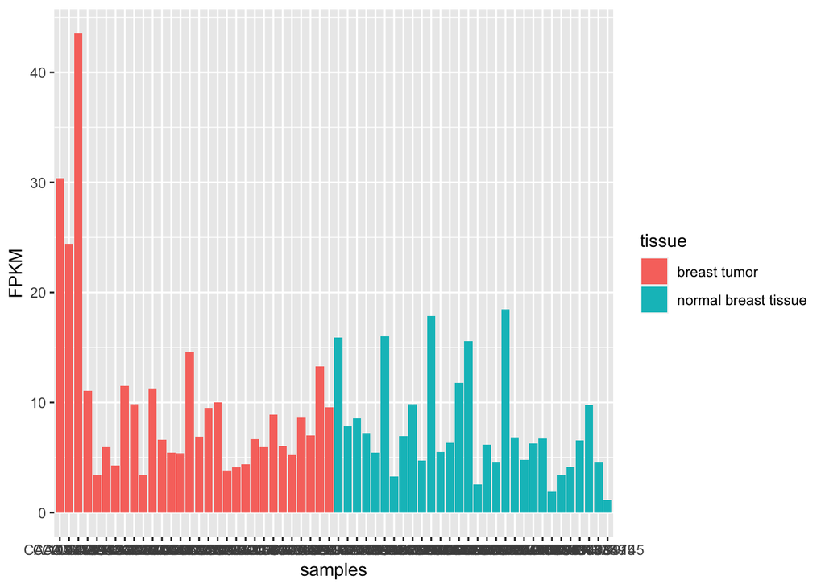

```r
data.long %>%
  filter(gene == "BRCA1") %>%
  ggplot(., aes(samples, FPKM, fill = tissue)) +
  geom_col()
```

4. Density Plot:
   - *Data:* `data.long` with filtering on the gene “BRCA1”.
   - *Plot Type:* Density plot using `geom_density()`.
   - *Purpose:* Visualizes the distribution of FPKM values for the gene “BRCA1” across different tissues. The plot shows the probability density of the expression levels.

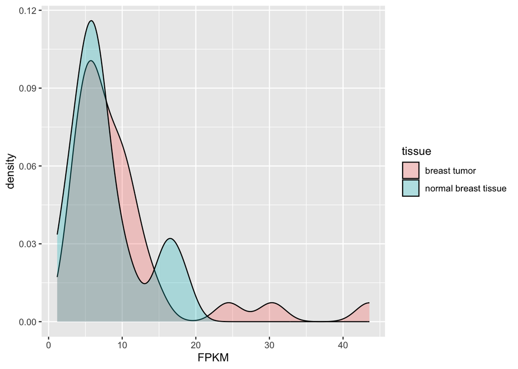

```r
data.long %>%
  filter(gene == "BRCA1") %>%
  ggplot(., aes(x = FPKM, fill = tissue)) +
  geom_density(alpha = 0.3)
```

5. Box and Violin Plot:
   - *Data:* `data.long` with filtering on the gene “BRCA1”.
   - *Plot Type:* Violin and Box plot using `geom_violin()` and `geom_boxplot()`.
   - *Purpose:* Depicts the distribution of FPKM values for the gene “BRCA1” among different metastasis types. The width of the violin plot indicates the density, and the shape provides insights into the data distribution.

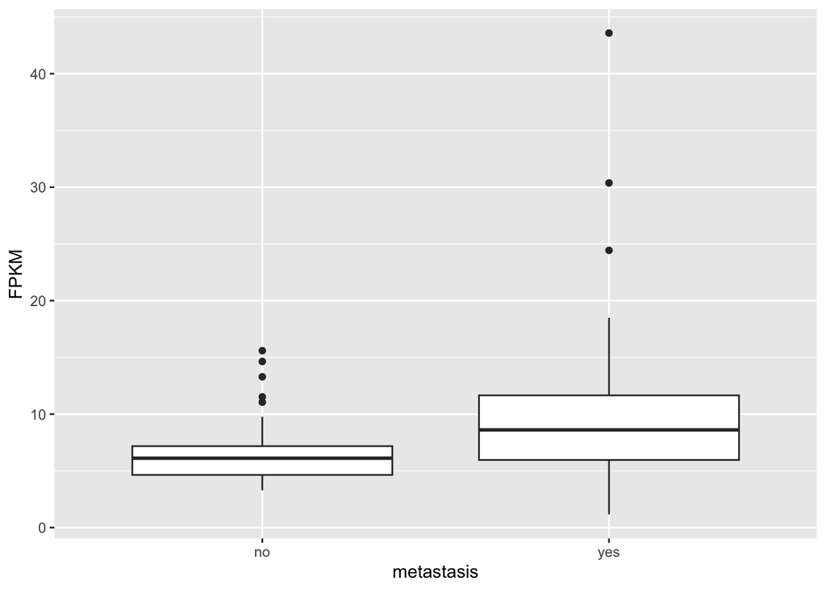

```r
data.long %>%
  filter(gene == "BRCA1") %>%
  ggplot(., aes(x = metastasis, y = FPKM)) +
  geom_boxplot()
```

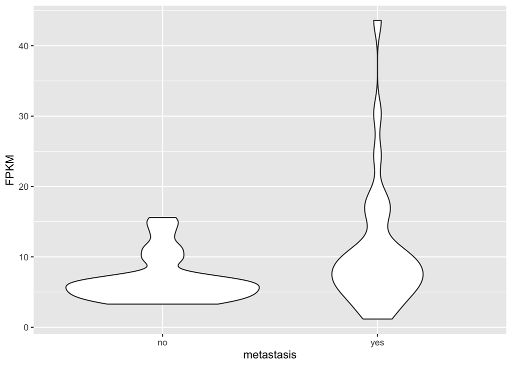

```r
data.long %>%
  filter(gene == "BRCA1") %>%
  ggplot(., aes(x = metastasis, y = FPKM)) +
  geom_violin()
```

6. Scatterplot:
   - *Data:* `data.long` with filtering on genes “BRCA1” and “BRCA2”.
   - *Plot Type:* Scatterplot using `geom_point()` with a linear regression line (`geom_smooth()`).
   - *Purpose:* Examines the correlation between the expression levels of “BRCA1” and “BRCA2” across different tissues. Each point represents a sample, and the color distinguishes tissues. The regression line indicates the trend in the relationship.

The `spread(key = gene, value = FPKM)` function is used to pivot the data. It transforms the long-format data, where each row represents a combination of gene, sample, and FPKM value, into a wide-format where each gene has its own column. The key parameter specifies the new column names (BRCA1 and BRCA2), and the value parameter indicates the values in those columns (FPKM).

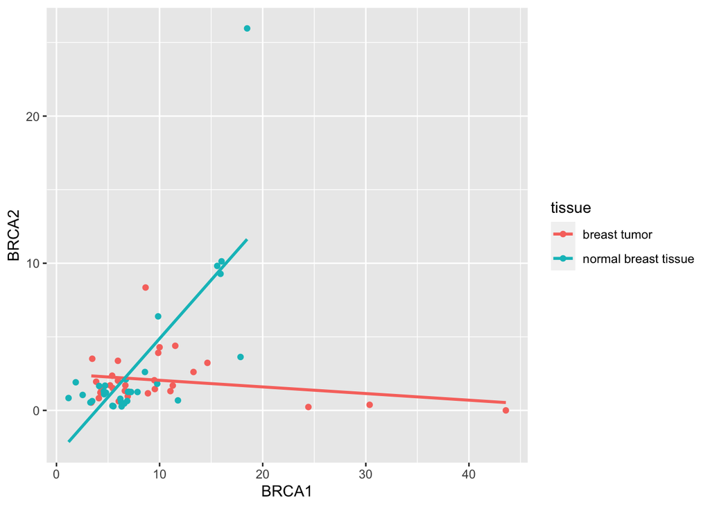

```r
data.long %>%
  filter(gene == "BRCA1" | gene == "BRCA2") %>%
  spread(key = gene, value = FPKM) %>%
  ggplot(., aes(x = BRCA1, y = BRCA2, color = tissue)) +
  geom_point() +
  geom_smooth(method = "lm", se = FALSE)
```

7. Heatmap:
   - *Data:* `data.long` with filtering on genes of interest (“BRCA1”, “BRCA2”, “TP53”, “ALK”, “MYCN”).
   - *Plot Type:* Heatmap using `geom_tile()` and color gradient with `scale_fill_gradient()`.
   - *Purpose:* Illustrates the expression levels (FPKM) of selected genes across different samples. Rows represent genes, columns represent samples, and the color intensity indicates the FPKM values. This plot is particularly useful for identifying patterns and relationships among the selected genes.

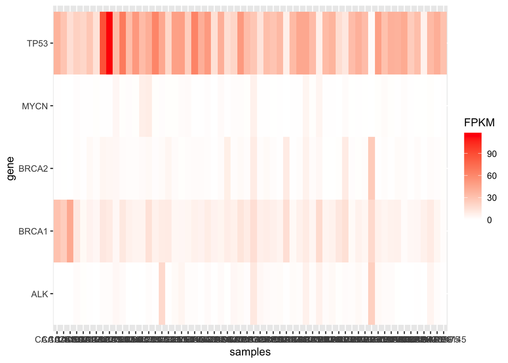

```r
genes.of.interest <- c("BRCA1", "BRCA2", "TP53", "ALK", "MYCN")

# pdf("heatmap_save2.pdf", width = 10, height = 8)
data.long %>%
  filter(gene %in% genes.of.interest) %>%
  ggplot(., aes(x = samples, y = gene, fill = FPKM)) +
  geom_tile() +
  scale_fill_gradient(low = "white", high = "red")
```

```r
# dev.off()
```